# Obesity_estimation_exploration_report

## Obesity Levels Based On Eating Habits and Physical Condition

### The dataset contains 2111 rows and 17 columns, with a mix of categorical and numerical variables. Here's a breakdown of the key columns:

- **Numerical variables**: Age, Height, Weight, FCVC, NCP, CH2O, FAF, TUE
- **Categorical variables**: Gender, family_history_with_overweight, FAVC, CAEC, SMOKE, SCC, CALC, MTRANS, NObeyesdad

### Dataset

Each row in the dataset represents one individual eating habits and physical condition and nutritional behavior. Columns with the description :

- **Gender** - Male or Female
- **Age**: A person's age may affect their metabolic rate and lifestyle, influencing obesity levels.
- **Height**: Useful for calculating Body Mass Index (BMI), which is closely related to obesity.
- **Weight**: One of the most critical variables for determining obesity.
- **Family_History_with_Overweight**: Whether a person has a genetic predisposition to being overweight or obese, which can significantly impact obesity risk.
- **FAVC** (Frequent Consumption of High-Calorie Food): This reflects dietary habits, particularly the consumption of high-calorie foods, which is a known risk factor for obesity.
- **FCVC** (Frequency of Consumption of Vegetables): A higher intake of vegetables is typically associated with a healthier diet and lower risk of obesity.
- **NCP** (Number of Meals): The number of meals consumed daily can impact weight gain, especially if portion sizes are not controlled.
- **CAEC** (Consumption of Food Between Meals): Eating snacks or meals outside of regular eating hours can contribute to weight gain.
- **SMOKE** (Smoking Habit): Smoking status can influence metabolism and overall health, affecting obesity.
- **CH20** (Water Intake: Adequate water intake can aid in digestion and prevent overeating, indirectly influencing weight management.
- **CALC** (Calories Consumed): Regular or frequent alcohol consumption adds extra calories, contributing to weight gain.
- **FAF** (Physical Activity Frequency): Frequency of physical activity is a key factor in energy expenditure and weight control.
- **TUE** (Time Spent Using Technology): Time spent on technology or screens is often linked to sedentary behavior, which can contribute to obesity.
- **MTRANS** (Transportation Mode): The mode of transportation, such as walking or using public transportation, reflects levels of physical activity in daily life.

The target column is **NObeyesdad** - Obesity level, which we will try to predict based on the other features in the dataset.

*Attributes related with eating habits are:*

```
- Frequent consumption of high caloric food (FAVC),

- Frequency of consumption of vegetables (FCVC),

- Number of main meals (NCP),

- Consumption of food between meals (CAEC),

- Consumption of water daily (CH20),

- Consumption of alcohol (CALC).
```

*Attributes related with the physical condition are:*

```
- Calories consumption monitoring (SCC),

- Physical activity frequency (FAF),

- Time using technology devices (TUE),

- Transportation used (MTRANS),
```

*Other variables were:*

```
- Gender

- Age

- Height

- Weight
```

This dataset was obtained from the UCI Machine Learning Repository, a well-known resource for datasets in the machine learning community.

### Import required packages and dataset

```python
%load_ext dotenv
%dotenv
```

```
The dotenv extension is already loaded. To reload it, use:
  %reload_ext dotenv
```

```python
%reload_ext dotenv
```

```python
# Import standard libraries
import pandas as pd
import matplotlib.pyplot as plt
import seaborn as sns
import warnings
warnings.filterwarnings('ignore')
import os
import sys

sys.path.append(os.getenv('SRC_DIR'))
```

### Load the data set into dataframe

```python
# Load the dataset
from DataManager import get_data

obesity_df = get_data('../data/ObesityDataSet_raw_and_data_sinthetic.csv')
obesity_df.shape
```

```
Getting data from ../data/ObesityDataSet_raw_and_data_sinthetic.csv
```

```
(2111, 17)
```

### Display basic information about the dataset

```python
obesity_df.head()
```

|  | Gender | Age | Height | Weight | family_history_with_overweight | FAVC | FCVC | NCP | CAEC | SMOKE | CH2O | SCC | FAF | TUE | CALC | MTRANS | NObeyesdad |
| --- | --- | --- | --- | --- | --- | --- | --- | --- | --- | --- | --- | --- | --- | --- | --- | --- | --- |
| 0 | Female | 21.0 | 1.62 | 64.0 | yes | no | 2.0 | 3.0 | Sometimes | no | 2.0 | no | 0.0 | 1.0 | no | Public_Transportation | Normal_Weight |
| 1 | Female | 21.0 | 1.52 | 56.0 | yes | no | 3.0 | 3.0 | Sometimes | yes | 3.0 | yes | 3.0 | 0.0 | Sometimes | Public_Transportation | Normal_Weight |
| 2 | Male | 23.0 | 1.80 | 77.0 | yes | no | 2.0 | 3.0 | Sometimes | no | 2.0 | no | 2.0 | 1.0 | Frequently | Public_Transportation | Normal_Weight |
| 3 | Male | 27.0 | 1.80 | 87.0 | no | no | 3.0 | 3.0 | Sometimes | no | 2.0 | no | 2.0 | 0.0 | Frequently | Walking | Overweight_Level_I |
| 4 | Male | 22.0 | 1.78 | 89.8 | no | no | 2.0 | 1.0 | Sometimes | no | 2.0 | no | 0.0 | 0.0 | Sometimes | Public_Transportation | Overweight_Level_II |

### Renaming the columns for better readability

```python
#from DataManager import rename_columns
columnName = {'family_history_with_overweight': 'Family_History',
                                          'FAVC' : 'High_Cal_Foods_Frequently',
                                          'FCVC': 'Freq_Veg', 'NCP': 'Num_Meals',
                                          'CAEC': 'Snacking',
                                          'SMOKE': 'Smoke',
                                          'CH2O': 'Water_Intake',
                                          'SCC': 'Calorie_Monitoring' ,
                                          'FAF': 'Phys_Activity',
                                          'TUE': 'Tech_Use', 'CALC':
                                          "Freq_Alcohol",
                                          'MTRANS': 'Transportation',
                                          'NObeyesdad': 'Obesity_Level'}


obesity_df_renamed = obesity_df.rename(columns=columnName)
```

```python
obesity_df_renamed.info()
```

```
<class 'pandas.core.frame.DataFrame'>
RangeIndex: 2111 entries, 0 to 2110
Data columns (total 17 columns):
 #   Column                     Non-Null Count  Dtype
---  ------                     --------------  -----
 0   Gender                     2111 non-null   object
 1   Age                        2111 non-null   float64
 2   Height                     2111 non-null   float64
 3   Weight                     2111 non-null   float64
 4   Family_History             2111 non-null   object
 5   High_Cal_Foods_Frequently  2111 non-null   object
 6   Freq_Veg                   2111 non-null   float64
 7   Num_Meals                  2111 non-null   float64
 8   Snacking                   2111 non-null   object
 9   Smoke                      2111 non-null   object
 10  Water_Intake               2111 non-null   float64
 11  Calorie_Monitoring         2111 non-null   object
 12  Phys_Activity              2111 non-null   float64
 13  Tech_Use                   2111 non-null   float64
 14  Freq_Alcohol               2111 non-null   object
 15  Transportation             2111 non-null   object
 16  Obesity_Level              2111 non-null   object
dtypes: float64(8), object(9)
memory usage: 280.5+ KB
```

```python
obesity_df_renamed.describe()
```

|  | Age | Height | Weight | Freq_Veg | Num_Meals | Water_Intake | Phys_Activity | Tech_Use |
| --- | --- | --- | --- | --- | --- | --- | --- | --- |
| count | 2111.000000 | 2111.000000 | 2111.000000 | 2111.000000 | 2111.000000 | 2111.000000 | 2111.000000 | 2111.000000 |
| mean | 24.312600 | 1.701677 | 86.586058 | 2.419043 | 2.685628 | 2.008011 | 1.010298 | 0.657866 |
| std | 6.345968 | 0.093305 | 26.191172 | 0.533927 | 0.778039 | 0.612953 | 0.850592 | 0.608927 |
| min | 14.000000 | 1.450000 | 39.000000 | 1.000000 | 1.000000 | 1.000000 | 0.000000 | 0.000000 |
| 25% | 19.947192 | 1.630000 | 65.473343 | 2.000000 | 2.658738 | 1.584812 | 0.124505 | 0.000000 |
| 50% | 22.777890 | 1.700499 | 83.000000 | 2.385502 | 3.000000 | 2.000000 | 1.000000 | 0.625350 |
| 75% | 26.000000 | 1.768464 | 107.430682 | 3.000000 | 3.000000 | 2.477420 | 1.666678 | 1.000000 |
| max | 61.000000 | 1.980000 | 173.000000 | 3.000000 | 4.000000 | 3.000000 | 3.000000 | 2.000000 |

## Data Preprocessing

In this section, we will perform the following data quality checks to ensure the dataset is clean and ready for analysis:

1. **Check for Missing or Null Values**  
   Identify any missing or null values in the dataset and handle them appropriately (e.g., imputation or removal).
2. **Check for Uniqueness in Categories**  
   Verify the uniqueness of categorical data to ensure there are no inconsistencies or redundancies in the categories.
3. **Check for Duplicates**  
   Identify and remove duplicate rows to avoid redundant data that may skew the analysis.
4. **Check for Outliers**  
   Detect and handle outliers in numerical data using statistical methods or visualization techniques (e.g., boxplots, z-scores, or IQR).

```python
num_col = obesity_df_renamed.select_dtypes(include=['float64', 'int64']).columns
cat_col = obesity_df_renamed.select_dtypes(include=['object']).columns
```

### Missing values or null values

```python
# Find missing values
obesity_df_renamed.isna().sum()
```

```
Gender                       0
Age                          0
Height                       0
Weight                       0
Family_History               0
High_Cal_Foods_Frequently    0
Freq_Veg                     0
Num_Meals                    0
Snacking                     0
Smoke                        0
Water_Intake                 0
Calorie_Monitoring           0
Phys_Activity                0
Tech_Use                     0
Freq_Alcohol                 0
Transportation               0
Obesity_Level                0
dtype: int64
```

From the above analysis, we can confirm that the dataset does not contain any missing or null values. This ensures that no additional imputation or handling for missing data is required.

```python
obesity_df_renamed.isnull().sum() # check for null values
```

```
Gender                       0
Age                          0
Height                       0
Weight                       0
Family_History               0
High_Cal_Foods_Frequently    0
Freq_Veg                     0
Num_Meals                    0
Snacking                     0
Smoke                        0
Water_Intake                 0
Calorie_Monitoring           0
Phys_Activity                0
Tech_Use                     0
Freq_Alcohol                 0
Transportation               0
Obesity_Level                0
dtype: int64
```

Similarly with missing values data doesn't have any null values.

### Uniqueness Check for Categorical Variables

In this step, we analyze the categorical variables to ensure their values are unique and consistent. This involves:

1. Identifying all categorical columns in the dataset.
2. Checking the unique values in each categorical column.
3. Verifying that no redundant or inconsistent categories exist.

```python
# Get unique values for all categorical variables

unique_values_per_column = {col: obesity_df_renamed[col].unique() for col in cat_col}
# Display unique values for each column
for col, unique_vals in unique_values_per_column.items():
    print(f"Unique values in '{col}': {unique_vals}")
```

```
Unique values in 'Gender': ['Female' 'Male']
Unique values in 'Family_History': ['yes' 'no']
Unique values in 'High_Cal_Foods_Frequently': ['no' 'yes']
Unique values in 'Snacking': ['Sometimes' 'Frequently' 'Always' 'no']
Unique values in 'Smoke': ['no' 'yes']
Unique values in 'Calorie_Monitoring': ['no' 'yes']
Unique values in 'Freq_Alcohol': ['no' 'Sometimes' 'Frequently' 'Always']
Unique values in 'Transportation': ['Public_Transportation' 'Walking' 'Automobile' 'Motorbike' 'Bike']
Unique values in 'Obesity_Level': ['Normal_Weight' 'Overweight_Level_I' 'Overweight_Level_II'
 'Obesity_Type_I' 'Insufficient_Weight' 'Obesity_Type_II'
 'Obesity_Type_III']
```

**Results:**  
The analysis confirms that all categorical variables have unique and consistent values, with no irregularities detected.

### Check for Duplicates

In this step, we identify and handle duplicate rows in the dataset to ensure data integrity. The process includes:

1. Scanning the dataset for duplicate entries.
2. Counting the total number of duplicate rows (if any).
3. Removing duplicates to avoid redundant data affecting the analysis.

```python
# Find duplicated values

obesity_df_renamed.duplicated().sum()
```

```
np.int64(24)
```

### Observation - 24 values are duplicate

```python
# Show duplicated values if needed

#obesity_df_renamed[obesity_df_renamed.duplicated(keep=False)]
```

### Remove duplicates

```python
# remove duplicates from the dataset
from DataManager import drop_duplicates

data = drop_duplicates(obesity_df_renamed)
data.shape
```

```
(2087, 17)
```

### Outlier Detection

In this step, we analyze numerical variables to identify and handle potential outliers. Outliers are extreme values that can skew the analysis and affect model performance. The process includes:

1. **Visualization Techniques:**
   - Using boxplots to visually identify outliers in numerical data.
   - Plotting histograms or scatter plots to detect irregular distributions.
2. **Statistical Methods:**
   - Calculating z-scores to detect data points that are far from the mean.
   - Applying the Interquartile Range (IQR) method to identify values outside the acceptable range:
3. **Handling Outliers:**
   - Reviewing whether outliers are genuine or due to errors.
   - Deciding whether to remove, transform, or retain outliers based on their relevance to the analysis.

```python
def find_outliers_IQR(df,numeric_col):

   q1=df[numeric_col].quantile(0.25)
   q3=df[numeric_col].quantile(0.75)
   IQR=q3-q1
   outliers = df[((df[numeric_col]<(q1-1.5*IQR)) | (df[numeric_col]>(q3+1.5*IQR)))]
   return outliers
```

```python
numeric_columns = num_col
for column in numeric_columns:
    outliers = find_outliers_IQR(data, column)

    if outliers.empty:
        print(f"No outliers detected in column {column}")
    else:
        print(f"{len(outliers)} outliers detected in column {column}")
        print("Max outlier value:", str(outliers[column].max()))
        print("Min outlier value:", str(outliers[column].min()))
```

```
167 outliers detected in column Age
Max outlier value: 61.0
Min outlier value: 35.194089
1 outliers detected in column Height
Max outlier value: 1.98
Min outlier value: 1.98
1 outliers detected in column Weight
Max outlier value: 173.0
Min outlier value: 173.0
No outliers detected in column Freq_Veg
577 outliers detected in column Num_Meals
Max outlier value: 4.0
Min outlier value: 1.0
No outliers detected in column Water_Intake
No outliers detected in column Phys_Activity
No outliers detected in column Tech_Use
```

### Boxplot visualisation for Outliers detection

We will visualize only the columns we have outliers

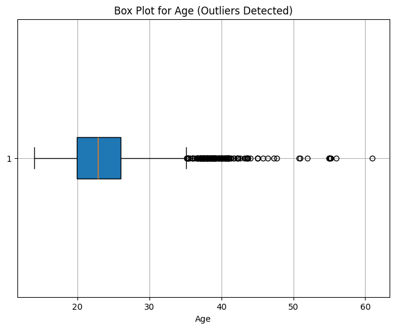

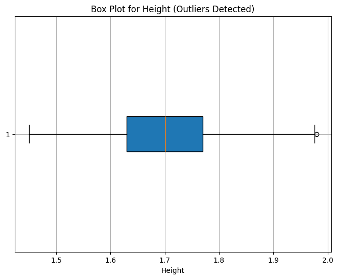

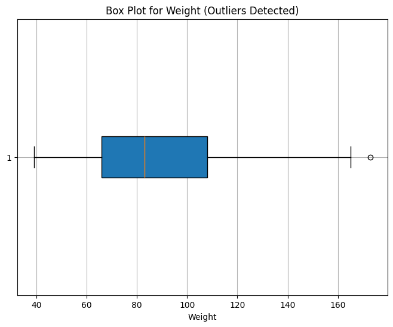

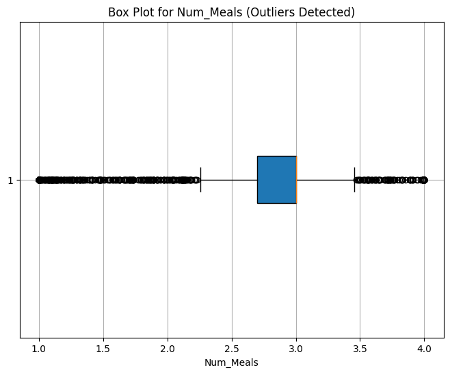

```python
for column in num_col:
    outliers = find_outliers_IQR(data, column)
    if not outliers.empty:  # Only plot if outliers are present
        plt.figure(figsize=(8, 6))
        plt.boxplot(data[column].dropna(), vert=False, patch_artist=True)
        plt.title(f"Box Plot for {column} (Outliers Detected)")
        plt.xlabel(column)
        plt.grid(True)
        plt.show()
```

### 1. Age distribution across different obesity levels (NObeyesdad)

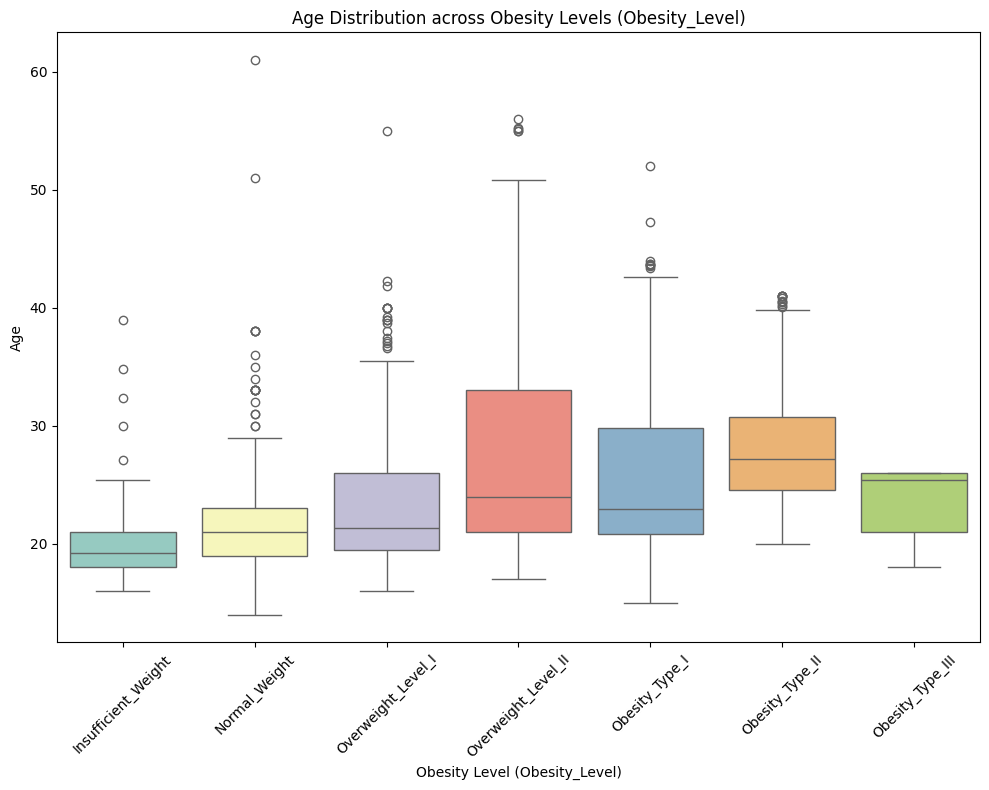

```python
# Age distribution across different obesity levels (NObeyesdad)

plt.figure(figsize=(10,8))
nobeyesdad_order = ['Insufficient_Weight', 'Normal_Weight', 'Overweight_Level_I','Overweight_Level_II','Obesity_Type_I', 'Obesity_Type_II', 'Obesity_Type_III']  # Adjust according to your dataset
sns.boxplot(x='Obesity_Level', y='Age', data=data, palette='Set3', order=nobeyesdad_order)
plt.title('Age Distribution across Obesity Levels (Obesity_Level)')
plt.xlabel('Obesity Level (Obesity_Level)')
plt.ylabel('Age')
plt.xticks(rotation=45)
plt.tight_layout()
plt.show()
```

## Age Distribution

From the figure below, it is evident that Age is right-skewed, suggesting that the dataset predominantly represents certain age groups. This could introduce a bias in the machine learning decision-making process. For now, we will retain the outliers and observe how the skewness of the Age feature impacts the model's performance. Depending on the results, we will decide whether to keep or remove the outliers during the feature engineering phase.

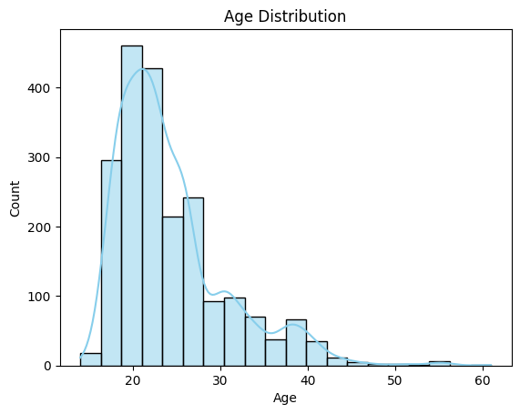

```python
sns.histplot(data['Age'], kde=True, bins=20, color='skyblue')
plt.title('Age Distribution')
```

### 2. Distribution of different target labels (NObeyesdad)

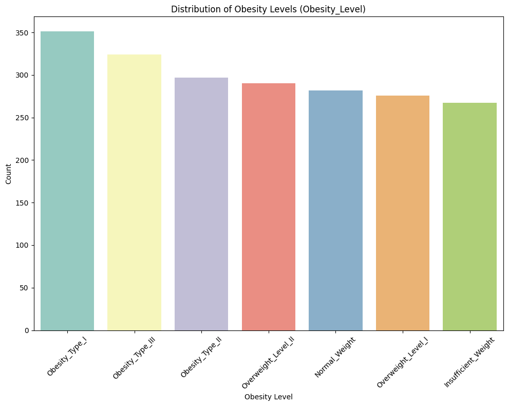

```python
# Define the order of obesity levels based on their frequency
nobeyesdad_order = data['Obesity_Level'].value_counts().index

plt.figure(figsize=(10,8))
sns.countplot(x='Obesity_Level', data=data, palette='Set3', order=nobeyesdad_order)
plt.title('Distribution of Obesity Levels (Obesity_Level)')
plt.xlabel('Obesity Level')
plt.ylabel('Count')
plt.xticks(rotation=45)
plt.tight_layout()
plt.show()
```

### Observation - We can see Obesity type I has highest percentage and then is Obestity_type III

### 3. Draw Pairplot to explore relationships between numerical variables

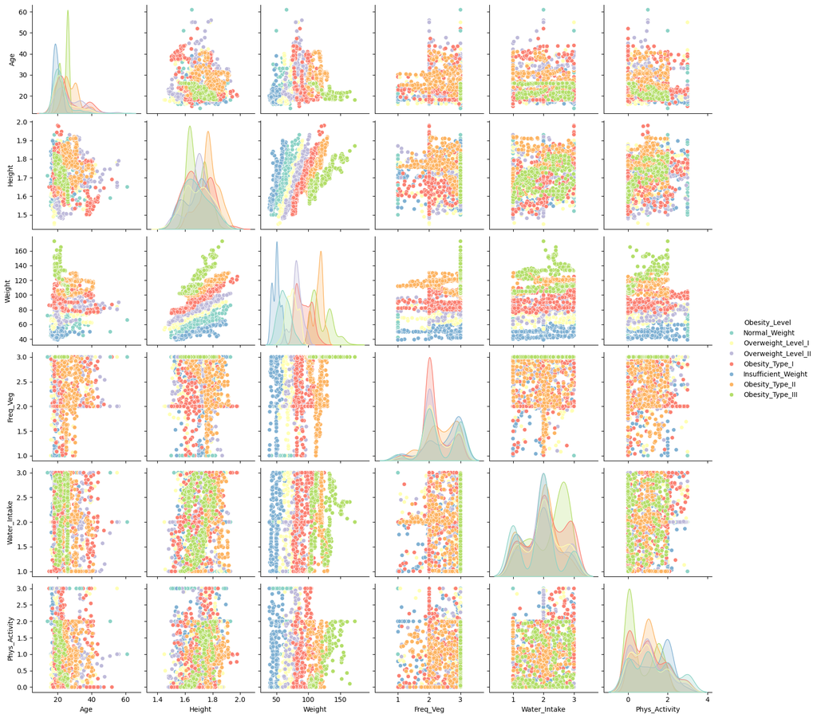

```python
sns.pairplot(data[['Age', 'Height', 'Weight', 'Freq_Veg', 'Water_Intake', 'Phys_Activity', 'Obesity_Level']], hue='Obesity_Level', palette='Set3')
plt.show()
```

In this scatter plot, we observe a strong linear relationship between Height and Weight, indicating potential multicollinearity. During feature engineering, this relationship might warrant consideration, such as removing one of the variables or using BMI (Body Mass Index) as a combined feature to better represent the data.

Other features, such as Frequency of Vegetable Consumption (FCVC), Water Intake (CH2O), and Physical Activity Frequency (FAF), do not exhibit a clear linear relationship with other variables. However, their monolithic behavior (clustered values) suggests they may behave more like categorical features despite being numerical. This observation should be considered in the preprocessing and modeling stages to ensure these features are treated appropriately.

### Categorical Column relationship with target

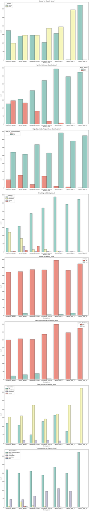

```python
# Define fixed palettes for different categorical variables
binary_palette = {"yes": "#8dd3c7", "no": "#fb8072"}
# Define the desired order of obesity levels
obesity_level_order = [
    "Insufficient_Weight",
    "Normal_Weight",
    "Overweight_Level_I",
    "Overweight_Level_II",
    "Obesity_Type_I",
    "Obesity_Type_II",
    "Obesity_Type_III"
]
plt.figure(figsize=(12, 170))
counter = 1
for var in cat_col:
    if counter < len(cat_col):
        plt.subplot(20, 1, counter)
        plt.title(f"{var} vs Obesity_Level")

        # Determine the appropriate palette based on variable categories
        if var in ["Family_History", "High_Cal_Foods_Frequently", "Smoke", "Calorie_Monitoring"]:
            palette = binary_palette  # Use "yes" and "no" palette
        else:
            palette = "Set3"  # Default palette for other categorical variables

        # Plot with the selected palette
        sns.countplot(
            x="Obesity_Level",
            hue=var,
            data=obesity_df_renamed,
            edgecolor="black",
            palette=palette,
            order=obesity_level_order
        )
    counter += 1
plt.tight_layout()
plt.show()
```

# Insights from Categorical Variable Analysis

## Family History with Overweight:

- The graphs shows that higher obesity level indiviuals has a family history with overweight.

## FAVC (Frequent Consumption of High-Caloric Food):

- The graph indicates that frequent consumption of high-caloric food is common across all obesity levels. We are observing that in higher obesity levels are more tend to consumpt high caloric foods.

## SMOKE:

- Smoking habits appear to have no significant association with obesity levels.
- In different categories it is mostly selected as 'No'.

## SCC (Calorie Monitoring):

- Individuals who monitor their calories tend to cluster more in normal and lower obesity categories.
- The graph shows that higher level of obesity level indivuals are nor doing a calorie monitoring.

## MTRANS (Mode of Transportation):

-Public transportation users are distributed across all obesity categories, while those who walk tend to be in lower obesity levels; however, there is no strong evidence that transportation type directly affects obesity levels, as factors like urban location or the socioeconomic status of individuals may also play a role.

### 4. Correlation Analysis

We will perform correlation analysis between numerical features with using Pearson Correlation coefficent.

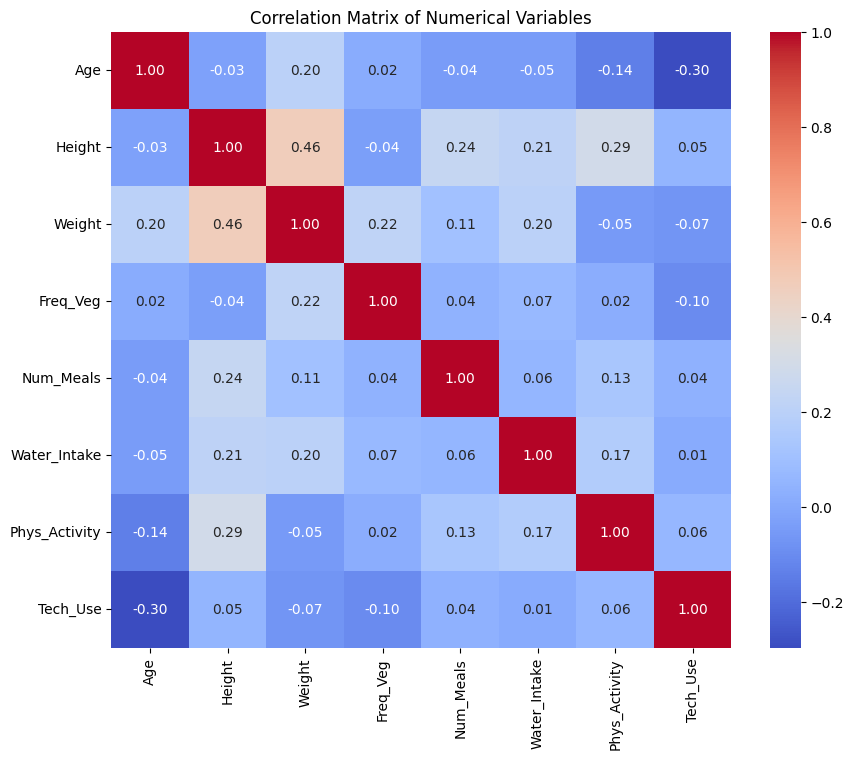

```python
# Let's start by performing correlation analysis, pair plots, and creating distribution plots.
# Create a heatmap for the correlation matrix using only numerical columns
# Automatically select numerical columns
numerical_columns = obesity_df_renamed.select_dtypes(include=['float64', 'int64']).columns
numerical_correlation_matrix = obesity_df_renamed[numerical_columns].corr()

# Plot the heatmap
plt.figure(figsize=(10, 8))
sns.heatmap(numerical_correlation_matrix, annot=True, cmap='coolwarm', fmt='.2f')
plt.title('Correlation Matrix of Numerical Variables')
plt.show()
```

### Observation - We noticed a relatively strong positive correlation between the Weight and Height.

**We will define a new variable (BMI = Weight/Height^2).**

### Feature Enginerring - Adding a new column **BMI** and explore its relationship with other features.

```python
# Define new variable of BMI

data['BMI'] = data['Weight'] / (data['Height'] ** 2)
```

### BMI distribution across different obesity levels (NObeyesdad)

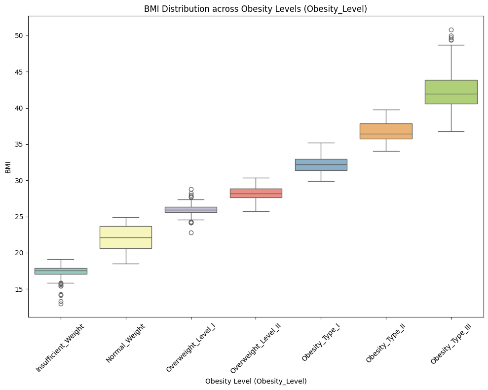

```python
# BMI distribution across different obesity levels (NObeyesdad)

plt.figure(figsize=(10,8))
nobeyesdad_order = ['Insufficient_Weight', 'Normal_Weight', 'Overweight_Level_I','Overweight_Level_II','Obesity_Type_I', 'Obesity_Type_II', 'Obesity_Type_III']  # Adjust according to your dataset
sns.boxplot(x='Obesity_Level', y='BMI', data=data, palette='Set3', order=nobeyesdad_order)
plt.title('BMI Distribution across Obesity Levels (Obesity_Level)')
plt.xlabel('Obesity Level (Obesity_Level)')
plt.ylabel('BMI')
plt.xticks(rotation=45)
plt.tight_layout()
plt.show()
```

### BMI distribution across different Genders

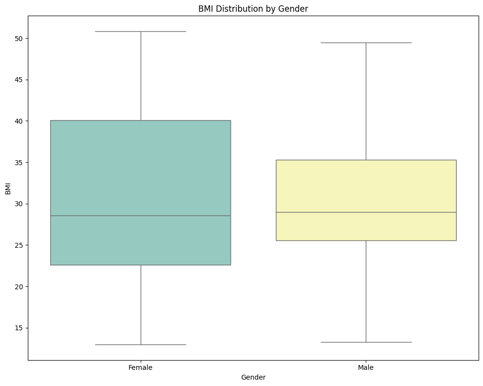

```python
# BMI distribution across different obesity levels (NObeyesdad)

plt.figure(figsize=(10,8))
sns.boxplot(x='Gender', y='BMI', data=data, palette='Set3')
plt.title('BMI Distribution by Gender')
plt.xlabel('Gender')
plt.ylabel('BMI')
plt.tight_layout()
plt.show()
```

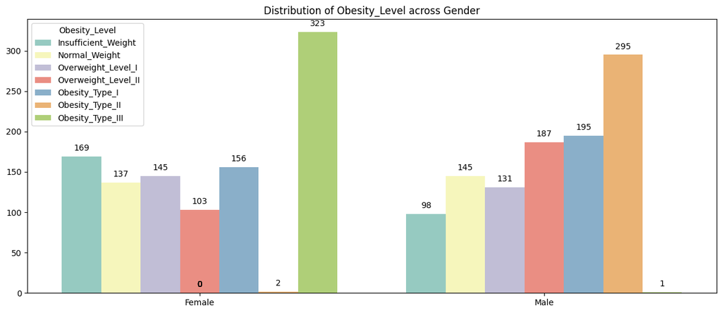

```python
plt.figure(figsize=(15,6))
ax = sns.countplot(x = "Gender", hue = "Obesity_Level",hue_order=nobeyesdad_order, data = data, palette='Set3')

for p in ax.patches:
    ax.annotate(format(p.get_height(), '.0f'),
               (p.get_x() + p.get_width() / 2, p.get_height()),
               ha = 'center', va = 'center',
               xytext = (0,10),
               textcoords = 'offset points')

plt.title("Distribution of Obesity_Level across Gender")
plt.xlabel('')
plt.ylabel('')


plt.show()
```

### Observation - 1) Obesity Type III is predominantly observed in females, 2) Obesity Type II is predominantly observed in males.

### BMI distribution by Age across different obesity levels (NObeyesdad)

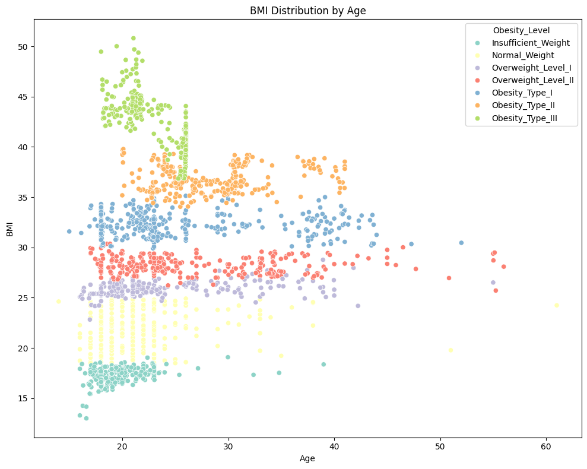

```python
# BMI distribution by Age across different obesity levels (NObeyesdad)

plt.figure(figsize=(10,8))
sns.scatterplot(x='Age', y='BMI', data=data, hue_order= nobeyesdad_order,hue='Obesity_Level', palette='Set3')

plt.title('BMI Distribution by Age')
plt.xlabel('Age')
plt.ylabel('BMI')
plt.tight_layout()
plt.show()
```

### Observation - Obesity type III is more commonly observed in individuals under the age of 30.

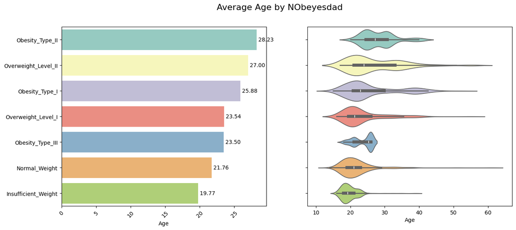

```python
nobe_bmi_mean = data.groupby('Obesity_Level')['Age'].mean().reset_index()

nobe_bmi_mean_sorted = nobe_bmi_mean.sort_values(by='Age', ascending = False)

fig, axes = plt.subplots(1,2,figsize=(15,6))
sns.barplot(y='Obesity_Level', x='Age',ax=axes[0],data=nobe_bmi_mean,order=nobe_bmi_mean_sorted['Obesity_Level'],palette='Set3')

for index, row in enumerate(nobe_bmi_mean_sorted.iterrows()):
    axes[0].text(row[1]['Age'], index, f"{row[1]['Age']: .2f}", va = 'center', ha = 'left', fontsize = 10)

axes[0].set_xlabel('Age')
axes[0].set_ylabel('')
axes[0].set_xticklabels(axes[0].get_xticklabels(), rotation=45)

sns.violinplot(y = "Obesity_Level", x= "Age", data= data, ax=axes[1], order=nobe_bmi_mean_sorted['Obesity_Level'],palette='Set3')
axes[1].set_ylabel('')
axes[1].set_yticklabels([])

fig.suptitle('Average Age by NObeyesdad', fontsize = 16)
plt.show()
```

### Observation - Normal Weight or Insufficient weight people seems to be younger on an average than the rest

### BMI distribution by Family History with Overweight across different obesity levels (NObeyesdad)

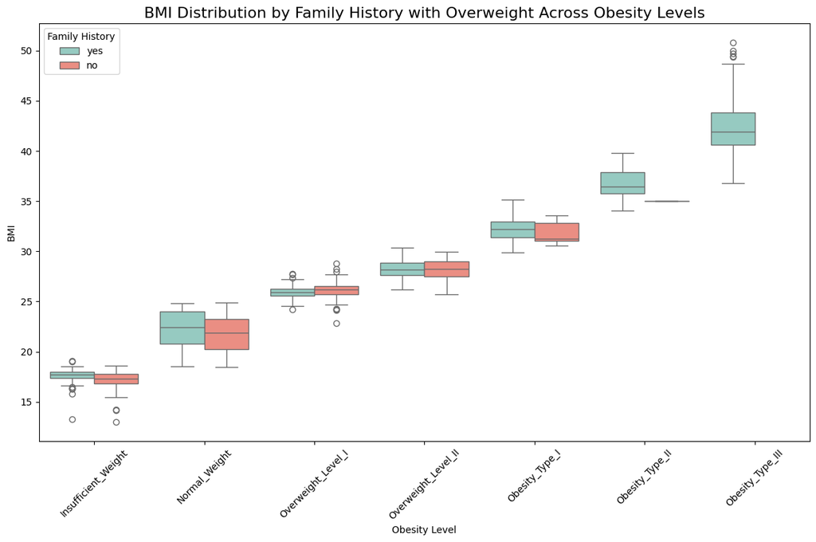

```python
# Plot BMI distribution by Family History with Overweight across Obesity Levels
binary_palette = {"yes": "#8dd3c7", "no": "#fb8072"}

plt.figure(figsize=(12, 8))
sns.boxplot(
    x='Obesity_Level',
    y='BMI',
    hue ='Family_History',
    data=data,
    palette= binary_palette,
    order=obesity_level_order
)
plt.title("BMI Distribution by Family History with Overweight Across Obesity Levels", fontsize=16)
plt.xlabel("Obesity Level")
plt.ylabel("BMI")
plt.xticks(rotation=45)
plt.legend(title="Family History", loc='upper left')
plt.tight_layout()
plt.show()
```

### There is a strong evidence higher BMI levels have a family history of obesity.

### Observation - No cases of obesity level III have been observed in individuals without a family history of overweight, suggesting that family history plays a significant role, at least in the development of obesity level III.

### BMI distribution by Frequent Consumption of High-Calorie Food (FAVC) across different obesity levels (NObeyesdad)

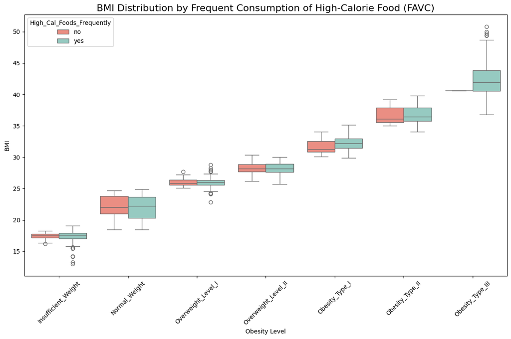

```python
# Plot BMI distribution by Family History with Overweight across Obesity Levels
binary_palette = {"yes": "#8dd3c7", "no": "#fb8072"}

plt.figure(figsize=(12, 8))
sns.boxplot(
    x='Obesity_Level',
    y='BMI',
    hue ='High_Cal_Foods_Frequently',
    data=data,
    palette= binary_palette,
    order=obesity_level_order
)
plt.title("BMI Distribution by Frequent Consumption of High-Calorie Food (FAVC)", fontsize=16)
plt.xlabel("Obesity Level")
plt.ylabel("BMI")
plt.xticks(rotation=45)
plt.legend(title="High_Cal_Foods_Frequently", loc='upper left')
plt.tight_layout()
plt.show()
```

### Observation - There is only one case of Obesity Type III where frequent consumption of high-calorie food is not present, suggesting that frequent consumption of high-calorie food likely plays a key role in the development of Obesity Type III. For other types of obesity and normal weight individuals, the distribution of high-calorie food consumption appears to be similar across all levels.

### BMI distribution by Number of Meals (NCP) across different obesity levels (NObeyesdad)

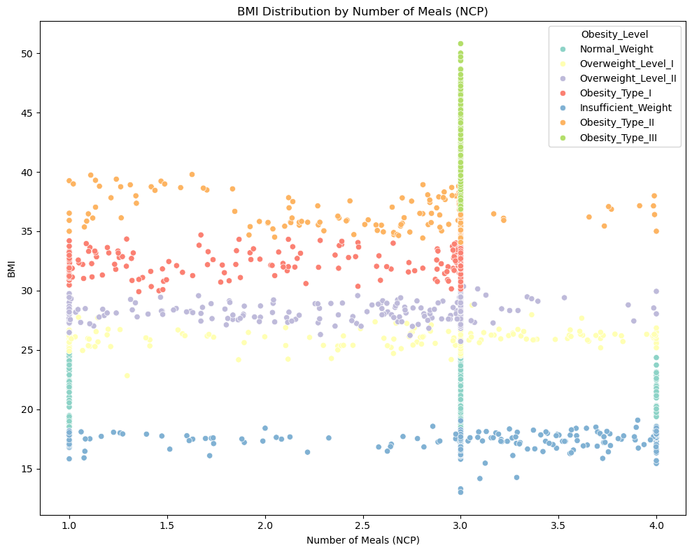

```python
# BMI distribution by Number of Meals (NCP) across different obesity levels (NObeyesdad)

plt.figure(figsize=(10,8))
sns.scatterplot(x='Num_Meals', y='BMI', data=obesity_df_renamed, hue='Obesity_Level', palette='Set3')

plt.title('BMI Distribution by Number of Meals (NCP)')
plt.xlabel('Number of Meals (NCP)')
plt.ylabel('BMI')
plt.tight_layout()
plt.show()
```

### Observation - Obestiy type III are mostly consuming 3 meals where as normal weight people are consuming 1, 3 or 4 meals

### BMI distribution by Smoking Habit (SMOKE) across different obesity levels (NObeyesdad)

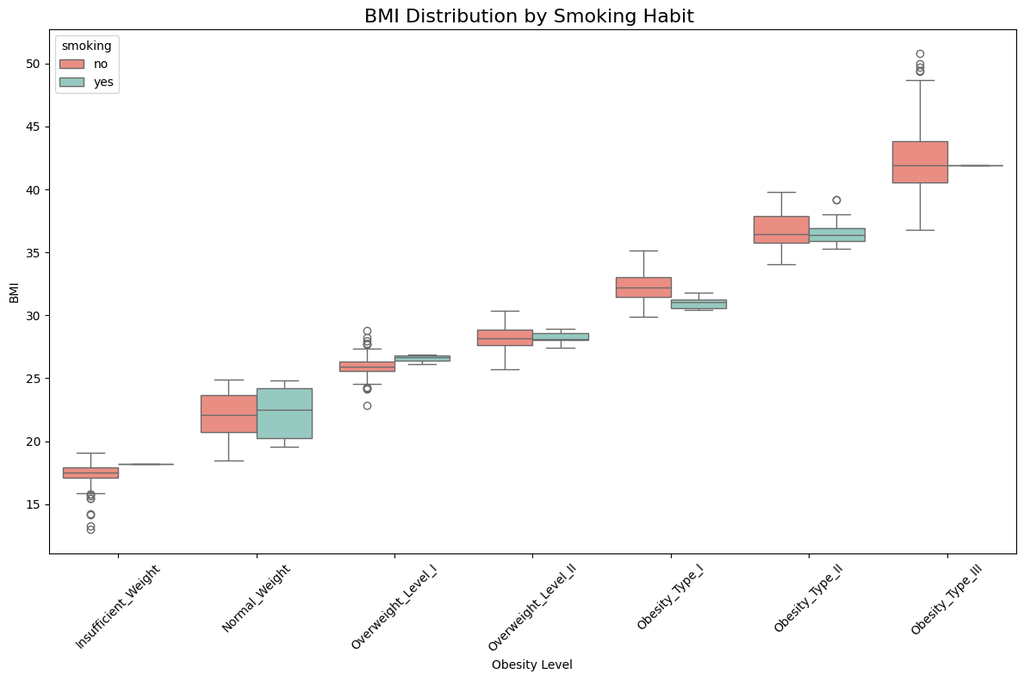

```python
# Plot BMI distribution by Smoking across Obesity Levels
binary_palette = {"yes": "#8dd3c7", "no": "#fb8072"}

plt.figure(figsize=(12, 8))
sns.boxplot(
    x='Obesity_Level',
    y='BMI',
    hue ='Smoke',
    data=data,
    palette= binary_palette,
    order=obesity_level_order
)
plt.title("BMI Distribution by Smoking Habit ", fontsize=16)
plt.xlabel("Obesity Level")
plt.ylabel("BMI")
plt.xticks(rotation=45)
plt.legend(title="smoking", loc='upper left')
plt.tight_layout()
plt.show()
```

### There is insufficient evidence to conclude that smoking has a significant effect on obesity levels. The primary observation is that individuals in Obesity Level III are predominantly non-smokers.

```python
def show_pie_chart(df, column_name):

    # Converting string values to categorical
    df[column_name] = df[column_name].astype('category')

    # Calculating the frequency of values in the column
    counts = df[column_name].value_counts()


    # Sorting the values in the column by their frequency in descending order
    counts_sorted = counts.sort_values(ascending=False)

    # subplot
    fig,axes = plt.subplots(1, 2, figsize=(16, 8))
    plt.title(column_name)
    plt.subplots_adjust(wspace = 0.5)


    axes[0].pie(counts.values, labels=counts_sorted.index, autopct='%1.1f%%', startangle=140, colors=sns.color_palette("pastel"))

    sns.countplot(data=df, y=column_name, ax=axes[1], order=counts_sorted.index, palette="pastel", hue=column_name, legend=False, width=0.8)
    axes[1].set_ylabel('')
    axes[1].set_xlabel('')

    for i, v in enumerate(counts_sorted.values):
        axes[1].text(v + 0.1, i, str(v), ha='left', va = 'center', color = 'black', fontweight = 'bold')
    #plt.title(column_name)
    plt.show()
```

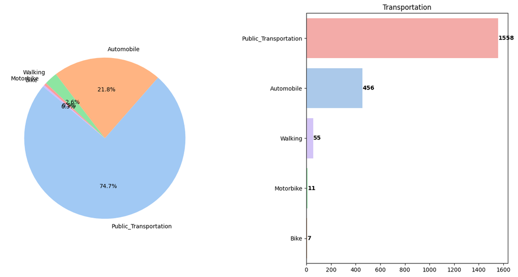

```python
 #Create pie chart for MTRANS
show_pie_chart(data, 'Transportation')
```

## Exporting the clean data

```python
data.to_csv('clean_data.csv', index=False)
```